# Data Exploration and Visualization in R

Tan Chu Quan (Chloe)

22 November 2020

## Introduction

In this document, the relationship between the resale price of flats in Singapore and its independent variables are explored. The results are visualized and the resale price is predicted using the independent variables.

## Source and selection of input data

The data was obtained from a [Singapore Public Housing Dataset on Kaggle](https://www.kaggle.com/lizexi/singapore-public-housing-dataset). Data obtained in August 2020 was chosen for building a model to price flat prices.

By convention, time series obtained during times of global economic instability is discouraged to be used for building models for prediction. There might be factors other than the ones given that affect the dependent variable to be predicted. Data from August 2020 was chosen as there were no news in that time period that might be followed by shocks in flat prices, as far as I know of.

These is the first 5 rows of the input table. A new column `remaining_lease_months` was created by converting `remaining_lease` from years and months into months. A new column `storey` was created by finding the average storey in `storey_range`. For example, if a flat is in the `storey_range` 01 TO 03, `storey` is 2.

|  | ï..month | town | flat_type | addresses | storey_range | storey | floor_area_sqm | flat_model | lease_commence_date | remaining_lease | remaining_lease_months | resale_price | searchval | X | Y | lat | long | distanceWithMrt | distanceWithRaffles | distanceWithGdPri |
| --- | --- | --- | --- | --- | --- | --- | --- | --- | --- | --- | --- | --- | --- | --- | --- | --- | --- | --- | --- | --- |
| 1 | 2020-08 | ANG MO KIO | 3 ROOM | 331 ANG MO KIO AVE 1 | 01 TO 03 | 2 | 68 | New Generation | 1981 | 59 years 06 months | 714 | 274000 | TECK GHEE VIEW | 29941.75 | 38240.88 | 1.362111 | 103.8508 | 881.0034 | 8703.096 | 1041.996 |
| 2 | 2020-08 | ANG MO KIO | 3 ROOM | 333 ANG MO KIO AVE 1 | 07 TO 09 | 8 | 68 | New Generation | 1981 | 59 years 06 months | 714 | 315000 | TECK GHEE VIEW | 30045.48 | 38155.87 | 1.361343 | 103.8517 | 985.4906 | 8617.203 | 1048.317 |
| 3 | 2020-08 | ANG MO KIO | 3 ROOM | 307C ANG MO KIO AVE 1 | 16 TO 18 | 17 | 70 | Model A | 2012 | 91 years 01 month | 1093 | 500000 | TECK GHEE VISTA | 29318.87 | 38622.32 | 1.365561 | 103.8452 | 689.4791 | 9113.712 | 1199.434 |
| 4 | 2020-08 | ANG MO KIO | 3 ROOM | 331 ANG MO KIO AVE 1 | 01 TO 03 | 2 | 82 | New Generation | 1981 | 59 years 05 months | 713 | 315000 | TECK GHEE VIEW | 29941.75 | 38240.88 | 1.362111 | 103.8508 | 881.0034 | 8703.096 | 1041.996 |
| 5 | 2020-08 | ANG MO KIO | 3 ROOM | 471 ANG MO KIO AVE 10 | 04 TO 06 | 5 | 67 | New Generation | 1979 | 58 years | 696 | 235000 | TECK GHEE HORIZON | 30602.40 | 38390.67 | 1.363466 | 103.8567 | 1072.5978 | 8872.729 | 1542.267 |

These are the columns used for data exploration.

|  | town | flat_model | flat_type | floor_area_sqm | storey | lease_commence_date | remaining_lease_months | distanceWithMrt | distanceWithRaffles | distanceWithGdPri | resale_price |
| --- | --- | --- | --- | --- | --- | --- | --- | --- | --- | --- | --- |
| 1 | ANG MO KIO | New Generation | 3 ROOM | 68 | 2 | 1981 | 714 | 881.0034 | 8703.096 | 1041.996 | 274000 |
| 2 | ANG MO KIO | New Generation | 3 ROOM | 68 | 8 | 1981 | 714 | 985.4906 | 8617.203 | 1048.317 | 315000 |
| 3 | ANG MO KIO | Model A | 3 ROOM | 70 | 17 | 2012 | 1093 | 689.4791 | 9113.712 | 1199.434 | 500000 |
| 4 | ANG MO KIO | New Generation | 3 ROOM | 82 | 2 | 1981 | 713 | 881.0034 | 8703.096 | 1041.996 | 315000 |
| 5 | ANG MO KIO | New Generation | 3 ROOM | 67 | 5 | 1979 | 696 | 1072.5978 | 8872.729 | 1542.267 | 235000 |

## Data exploration

The most noticeable link between `resale_price` and the indepedent variables is its correlation with `floor_area_sqm`. There is a positive correlation between `resale_price` and `floor_area_sqm` as shown in Figure 1A.

To factor `floor_area_sqm` into `resale_price`, `resale_price` was divided by `floor_area_sqm` to obtain `price_per_sqm`. There is no correlation between `price_per_sqm` and `floor_area_sqm` as shown in Figure 1B.

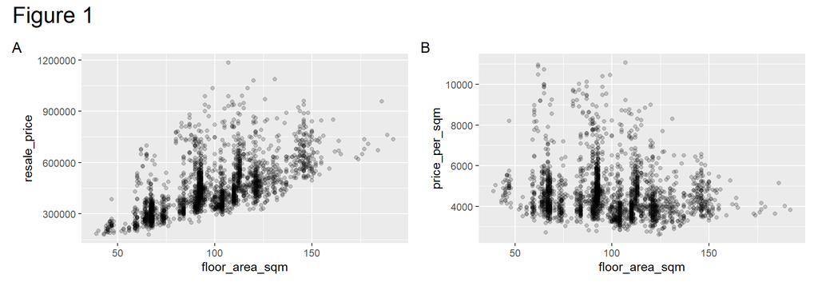

The relationship between `price_per_sqm` and `remaining_lease_months`, `distanceWithRaffles`, `distanceWithMrt` and `distanceWithMrt` is shown in Figure 2. There is a slight negative correlation between `price_per_sqm` and `distanceWithRaffles`.

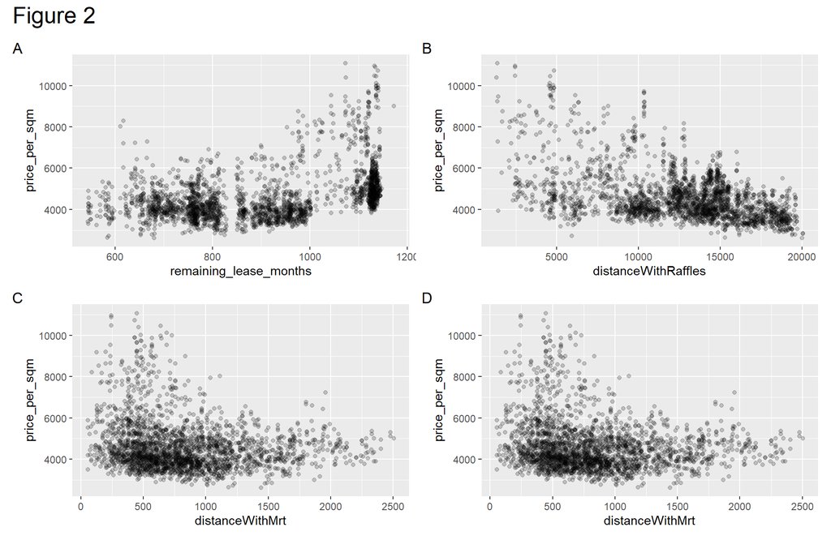

The median `price_per_sqm` is different between towns, as shown in Figure 3A. Flats in towns with higher connectivity and flats in towns that are close to important places tend to have higher prices. Bukit merah, Central Area, Marine Parade are within or on the edge of the CBD. Bishan has a high connectivity with the rest of the island with 3 MRT lines running through Bishan MRT Station and it is close to Orchard. Queenstown is close to Orchard by bus and it is close to NUS, NUH, Singapore Polytechnic, Biopolis and Fusionopolis. Towns such as Woodlands, Choa Chu Kang and Sembawang with lower connectivity and are further from the Central Area tend to have lower prices.

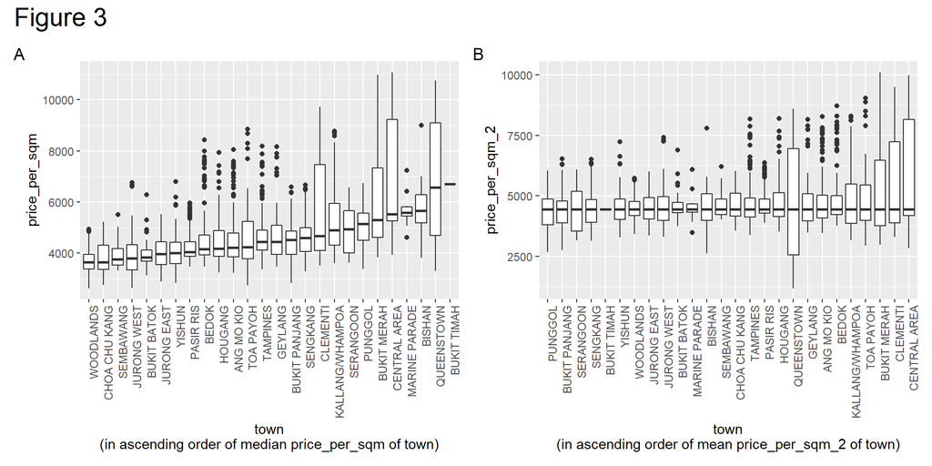

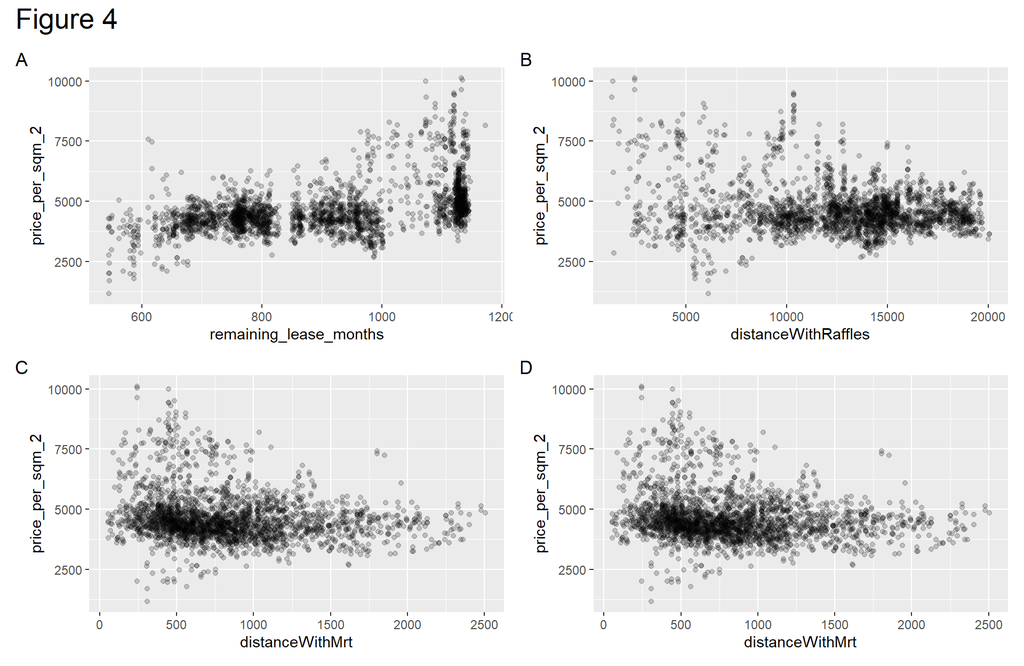

There is no difference in the median `price_per_sqm_2` by `flat_type`, as shown in Figure 5.

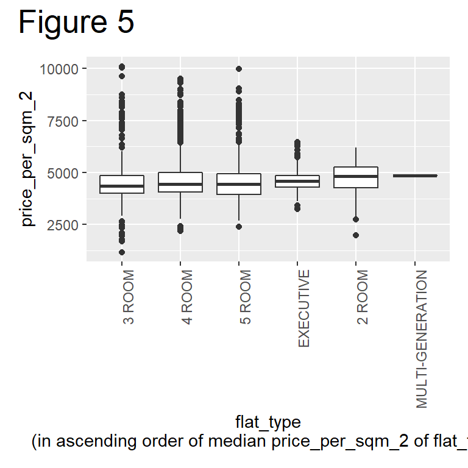

There are differences in median `price_per_sqm_2` and `price_per_sqm_2` ranges between flat models (Figure 6A).

One possible reason for the difference in `price_per_sqm_2` of flat models is the scarcity of the flat models. Flat models that are fewer in numbers in Singapore have higher prices. The frequency of the flat models in the input data was used as an indicator of the abundance of the flat models in Singapore. The boxplot in Figure 6A is reordered by descending frequency of flat models in Figure 6B. The hypothesis appears to be false.

The boxplot of `lease_commence_date` by `flat_model` is shown in Figure 6C. The flat models with 5 highest median `price_per_sqm_2` have later lease commence dates, except for Terrace. Another possible reason for the difference in `price_per_sqm_2` of flat models is the “newness” of the flat models.

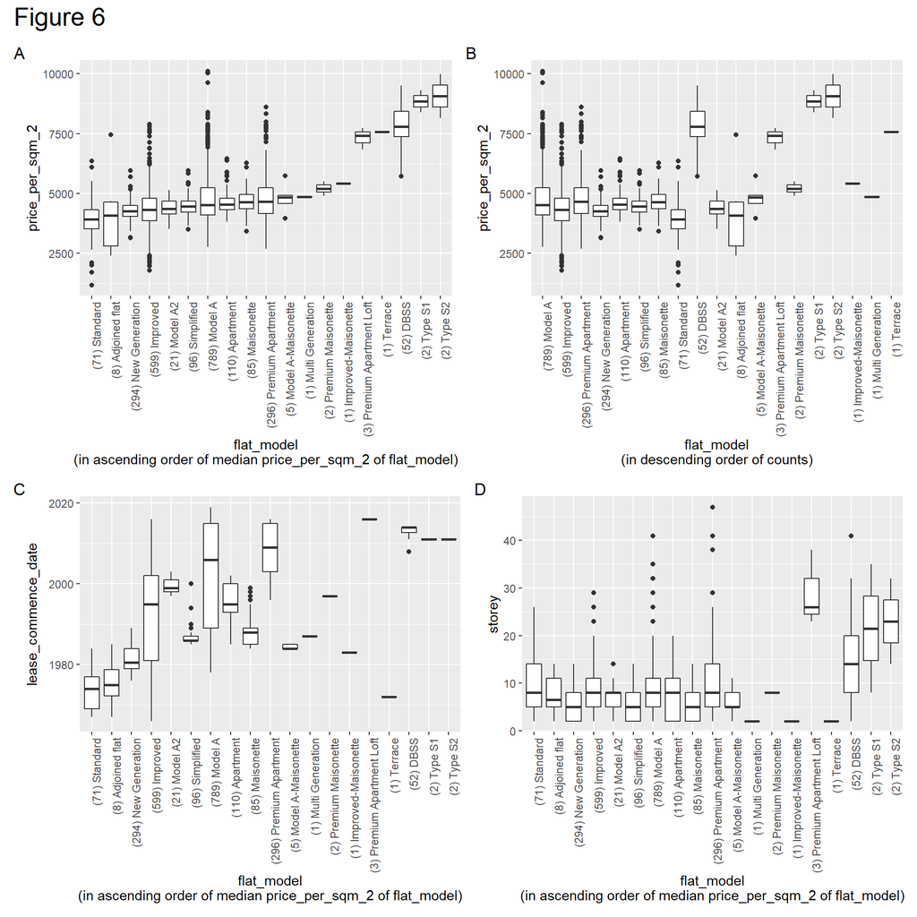

Flats on higher storeys have higher median `price_per_sqm_2` (Figure 7A). Flats on higher storeys (29 to 47) have generally higher prices.

The boxplot of `lease_commence_date` by `storey` is shown in Figure 7C. The storeys with 5 highest median `price_per_sqm_2` have later lease commence dates.

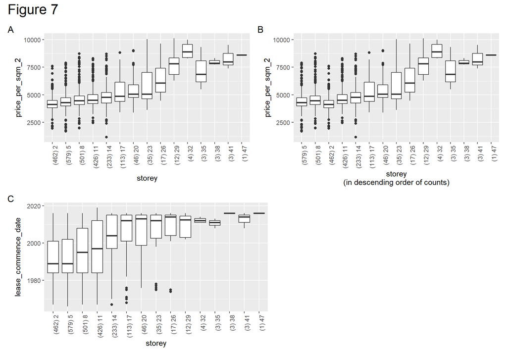

## Prediction of resale price

It is known that `price_per_sqm_2` have no relationship with `flat_type` (Figure 5) and it has an inconclusive relationship with `flat_model`.

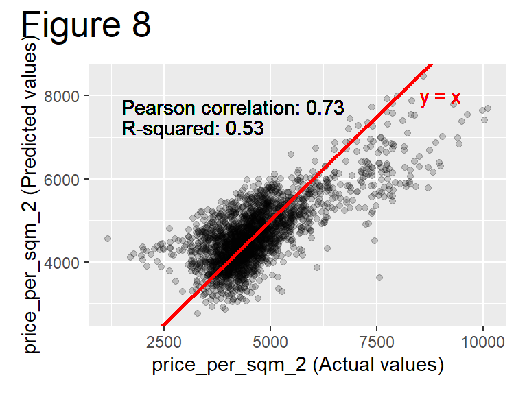

## Conclusion

Other than `floor_area_sqm` and `town`, the given factors cannot be used for predicting `resale_price` using a linear model. Future studies can include other factors and use other predictive models for predicting resale prices of flats in Singapore.